# Analyse der Wahlresultate von den Nationalratswahlen von 1991 bis 2023

Author

Barbara Sutter

```r
library(tidyverse)
library(dplyr)
library(ggplot2)
library(forcats)
library(ggthemes)
library(knitr)


read_csv2(here::here("daten/raw/sd-t-17.02-NRW2023-zeitreihen-parteien-APPENDIX (1).csv"))
```

```
# A tibble: 1,885 × 20
   wahl_jahr ebene_resultat geoLevelName kanton_nummer kanton_bezeichnung
       <dbl> <chr>          <chr>                <dbl> <chr>
 1      1991 Schweiz        Schweiz                 NA <NA>
 2      1991 Schweiz        Schweiz                 NA <NA>
 3      1991 Schweiz        Schweiz                 NA <NA>
 4      1991 Schweiz        Schweiz                 NA <NA>
 5      1991 Schweiz        Schweiz                 NA <NA>
 6      1991 Schweiz        Schweiz                 NA <NA>
 7      1991 Schweiz        Schweiz                 NA <NA>
 8      1991 Schweiz        Schweiz                 NA <NA>
 9      1991 Schweiz        Schweiz                 NA <NA>
10      1991 Schweiz        Schweiz                 NA <NA>
# ℹ 1,875 more rows
# ℹ 15 more variables: partei_id <dbl>, partei_bezeichnung_de <chr>,
#   partei_bezeichnung_fr <chr>, partei_bezeichnung_it <chr>,
#   partei_bezeichnung_en <chr>, partei_staerke <chr>,
#   flag_staerkste_partei <dbl>, anzahl_listen <dbl>,
#   anzahl_kandidierende <dbl>, anzahl_kandidierende_f <dbl>,
#   anzahl_kandidierende_m <dbl>, anzahl_gewaehlte <dbl>, …
```

```r
read_delim(here::here("daten/raw/sd-t-17.02-NRW2023-zeitreihen-parteien-APPENDIX (1).csv"), delim = ";")
```

```
# A tibble: 1,885 × 20
   wahl_jahr ebene_resultat geoLevelName kanton_nummer kanton_bezeichnung
       <dbl> <chr>          <chr>                <dbl> <chr>
 1      1991 Schweiz        Schweiz                 NA <NA>
 2      1991 Schweiz        Schweiz                 NA <NA>
 3      1991 Schweiz        Schweiz                 NA <NA>
 4      1991 Schweiz        Schweiz                 NA <NA>
 5      1991 Schweiz        Schweiz                 NA <NA>
 6      1991 Schweiz        Schweiz                 NA <NA>
 7      1991 Schweiz        Schweiz                 NA <NA>
 8      1991 Schweiz        Schweiz                 NA <NA>
 9      1991 Schweiz        Schweiz                 NA <NA>
10      1991 Schweiz        Schweiz                 NA <NA>
# ℹ 1,875 more rows
# ℹ 15 more variables: partei_id <dbl>, partei_bezeichnung_de <chr>,
#   partei_bezeichnung_fr <chr>, partei_bezeichnung_it <chr>,
#   partei_bezeichnung_en <chr>, partei_staerke <dbl>,
#   flag_staerkste_partei <dbl>, anzahl_listen <dbl>,
#   anzahl_kandidierende <dbl>, anzahl_kandidierende_f <dbl>,
#   anzahl_kandidierende_m <dbl>, anzahl_gewaehlte <dbl>, …
```

# Einleitung

Im Rahmen einer Weiterbildung des Kantons Zürich - Data Science mit R - wird vertieften Einblick in die Anwendung von R ermöglicht. Als Abschlussprojekt des Kurses wird ein OGD-Datensatz verwendet. Somit soll der gewonnene Einblick direkt an einem eigenen Projekt angewendet und vertieft werden.

# Daten

Die in dem vorliegenden Projekt verwendeten Daten stammen von opendata.swiss und werden vom Bundesamt für Statistik zur Verfügung gestellt. Die Daten thematisieren die Nationalratswahlen der Schweiz und wurden am 30. November 2023 letztmals aktualisiert. Die Daten zeigen eine Zeitreihe zu den Listen, den Kandidierenden, der Parteistärke, der Anzahl Mandate, die Anzahl gewählter Frauen und Männern sowie die jeweils stärkste Partei der jeweiligen Nationalratswahlen. Die Daten sind auf Ebene Schweiz sowie auf Ebene der einzelnen Kantone vorhanden und beginnen im Jahr 1991 bis ins Jahr 2023.

Link: [Nationalratswahlen: Zeitreihen zu Listen, Kandidierenden, Parteistärken, Mandaten, gewählten Frauen und Männern, stärkste Partei (Schweiz und Kantone) | opendata.swiss](https://opendata.swiss/de/dataset/nationalratswahlen-zeitreihen-zu-listen-kandidierenden-parteistarken-mandaten-gewahlten-frauen-)

```r
NRW2023_zeitreihe <- read_delim(here::here("daten/raw/sd-t-17.02-NRW2023-zeitreihen-parteien-APPENDIX (1).csv"), delim = ";")

# view(NRW2023_zeitreihe)
```

# Analyse

## Analyseziele

Ziel der vorliegenden Abschlussarbeit soll sein, mittels den Daten aufzuzeigen, wie sich die Parteienstärken bei den Nationalratswahlen 2023 verhalten. Weiter soll im Detail betrachtet werden, wie sich die Parteienstärke im Kanton Zürich zwischen 1991 und 2023 verändert hat. Die vorliegende Abschlussarbeit soll weiter einen Fokus auf den Frauenanteil legen. Dazu stellen sich folgende Fragen: Ist hier eine Verschiebung zu einem höheren Frauenanteil im vorliegenden Analysezeitraum (1991 bis 2023) sichtbar? Wie hat sich der Frauenanteil auf nationaler Ebene innerhalb der Parteien entwickelt?

## Datenaufbereitung

```r
# Daten erkunden

glimpse(NRW2023_zeitreihe)
```

```
Rows: 1,885
Columns: 20
$ wahl_jahr              <dbl> 1991, 1991, 1991, 1991, 1991, 1991, 1991, 1991,…
$ ebene_resultat         <chr> "Schweiz", "Schweiz", "Schweiz", "Schweiz", "Sc…
$ geoLevelName           <chr> "Schweiz", "Schweiz", "Schweiz", "Schweiz", "Sc…
$ kanton_nummer          <dbl> NA, NA, NA, NA, NA, NA, NA, NA, NA, NA, NA, NA,…
$ kanton_bezeichnung     <chr> NA, NA, NA, NA, NA, NA, NA, NA, NA, NA, NA, NA,…
$ partei_id              <dbl> 1, 2, 3, 4, 5, 6, 7, 8, 9, 12, 13, 14, 16, 18, …
$ partei_bezeichnung_de  <chr> "FDP", "CVP", "SP", "SVP", "LPS", "LdU", "EVP",…
$ partei_bezeichnung_fr  <chr> "PLR", "PDC", "PS", "UDC", "PL", "AdI", "PEV", …
$ partei_bezeichnung_it  <chr> "PLR", "PPD", "PS", "UDC", "PLS", "AdI", "PEV",…
$ partei_bezeichnung_en  <chr> "FDP", "CVP", "SP", "SVP", "LPS", "LdU", "EVP",…
$ partei_staerke         <dbl> 20.9907635, 17.9994922, 18.4906920, 11.9009662,…
$ flag_staerkste_partei  <dbl> 1, 0, 0, 0, 0, 0, 0, 0, 0, 0, 0, 0, 0, 0, 0, 0,…
$ anzahl_listen          <dbl> 25, 36, 25, 18, 5, 10, 8, 2, 6, 8, 17, 14, 5, 1…
$ anzahl_kandidierende   <dbl> 267, 303, 267, 237, 35, 164, 130, 11, 72, 131, …
$ anzahl_kandidierende_f <dbl> 72, 83, 121, 40, 11, 64, 38, 4, 34, 84, 120, 43…
$ anzahl_kandidierende_m <dbl> 195, 220, 146, 197, 24, 100, 92, 7, 38, 47, 117…
$ anzahl_gewaehlte       <dbl> 44, 35, 41, 25, 10, 5, 3, 1, 2, 1, 14, 5, 1, 2,…
$ anzahl_gewaehlte_f     <dbl> 5, 4, 12, 3, 1, 1, 0, 0, 0, 1, 8, 0, 0, 0, 0, 8…
$ anzahl_gewaehlte_m     <dbl> 39, 31, 29, 22, 9, 4, 3, 1, 2, 0, 6, 5, 1, 2, 1…
$ frauen_anteil          <dbl> 11.36364, 11.42857, 29.26829, 12.00000, 10.0000…
```

```r
names(NRW2023_zeitreihe)
```

```
 [1] "wahl_jahr"              "ebene_resultat"         "geoLevelName"
 [4] "kanton_nummer"          "kanton_bezeichnung"     "partei_id"
 [7] "partei_bezeichnung_de"  "partei_bezeichnung_fr"  "partei_bezeichnung_it"
[10] "partei_bezeichnung_en"  "partei_staerke"         "flag_staerkste_partei"
[13] "anzahl_listen"          "anzahl_kandidierende"   "anzahl_kandidierende_f"
[16] "anzahl_kandidierende_m" "anzahl_gewaehlte"       "anzahl_gewaehlte_f"
[19] "anzahl_gewaehlte_m"     "frauen_anteil"
```

```r
nrow(NRW2023_zeitreihe)
```

```
[1] 1885
```

```r
ncol(NRW2023_zeitreihe)
```

```
[1] 20
```

```r
# Die Variablen, welche für die Auswertungen nicht gebraucht werden, werden gefiltert und einen neuen Datensatz "NRW2023_zeitreihe_d" erstellt

NRW2023_zeitreihe_d <- NRW2023_zeitreihe |>
  select(wahl_jahr, ebene_resultat, kanton_nummer, kanton_bezeichnung, partei_id, partei_bezeichnung_de, partei_staerke, flag_staerkste_partei, anzahl_listen, anzahl_kandidierende, anzahl_kandidierende_f, anzahl_kandidierende_m, anzahl_gewaehlte, anzahl_gewaehlte_f, anzahl_gewaehlte_m, frauen_anteil)

# view(NRW2023_zeitreihe_d)

# Es werden die Wahljahre betrachtet, welche im Datensatz vorhanden sind

NRW2023_zeitreihe_d |>
  distinct(wahl_jahr)
```

```
# A tibble: 9 × 1
  wahl_jahr
      <dbl>
1      1991
2      1995
3      1999
4      2003
5      2007
6      2011
7      2015
8      2019
9      2023
```

```r
# Es wird ein Datensatz erstellt, welcher zum einen nur die Resultate auf der Ebene Schweiz (NRW2023_zeitreihe_CH)  und zum anderen die Resultate nur auf kantonaler Ebene (NRW2023_zeitreihe_Kanton) enthält

NRW2023_zeitreihe_CH <- NRW2023_zeitreihe_d |>
  filter(ebene_resultat == "Schweiz")

# view(NRW2023_zeitreihe_CH)

NRW2023_zeitreihe_Kanton <- NRW2023_zeitreihe_d |>
  filter(ebene_resultat != "Schweiz")

# dasselbe wird danach auch für das Wahljahr 2023 auf nationaler Ebene erstellt

NRW2023_CH_2023 <- NRW2023_zeitreihe_CH |>
  filter(wahl_jahr == "2023")

# Die CVP und die Mitte-Partei wird über den gesamten Datensatz in CVP/Mitte umbenannt, sodass die Daten vergleichbar bleiben.

NRW2023_zeitreihe_Kanton |>
  mutate(partei_bezeichnung_de = case_when(
    partei_bezeichnung_de == "CVP" ~ "CVP/Mitte",
    partei_bezeichnung_de == "Mitte" ~ "CVP/Mitte",
    .default = partei_bezeichnung_de
  ))
```

```
# A tibble: 1,745 × 16
   wahl_jahr ebene_resultat kanton_nummer kanton_bezeichnung partei_id
       <dbl> <chr>                  <dbl> <chr>                  <dbl>
 1      1991 Kanton                     1 Zürich                     1
 2      1991 Kanton                     1 Zürich                     2
 3      1991 Kanton                     1 Zürich                     3
 4      1991 Kanton                     1 Zürich                     4
 5      1991 Kanton                     1 Zürich                     6
 6      1991 Kanton                     1 Zürich                     7
 7      1991 Kanton                     1 Zürich                    12
 8      1991 Kanton                     1 Zürich                    13
 9      1991 Kanton                     1 Zürich                    14
10      1991 Kanton                     1 Zürich                    16
# ℹ 1,735 more rows
# ℹ 11 more variables: partei_bezeichnung_de <chr>, partei_staerke <dbl>,
#   flag_staerkste_partei <dbl>, anzahl_listen <dbl>,
#   anzahl_kandidierende <dbl>, anzahl_kandidierende_f <dbl>,
#   anzahl_kandidierende_m <dbl>, anzahl_gewaehlte <dbl>,
#   anzahl_gewaehlte_f <dbl>, anzahl_gewaehlte_m <dbl>, frauen_anteil <dbl>
```

# Ergebnisse

Mittels Visualisierungen und Tabellen sollen die oben erwähnten Fragen beantwortet werden.

### 1. Parteienstärke bei den Nationalratswahlen 2023

Die Daten aus dem Wahljahr 2023 werden betrachtet und visualisiert

```r
NRW2023_CH_2023
```

```
# A tibble: 17 × 16
   wahl_jahr ebene_resultat kanton_nummer kanton_bezeichnung partei_id
       <dbl> <chr>                  <dbl> <chr>                  <dbl>
 1      2023 Schweiz                   NA <NA>                       1
 2      2023 Schweiz                   NA <NA>                       2
 3      2023 Schweiz                   NA <NA>                       3
 4      2023 Schweiz                   NA <NA>                       4
 5      2023 Schweiz                   NA <NA>                       7
 6      2023 Schweiz                   NA <NA>                       8
 7      2023 Schweiz                   NA <NA>                       9
 8      2023 Schweiz                   NA <NA>                      12
 9      2023 Schweiz                   NA <NA>                      13
10      2023 Schweiz                   NA <NA>                      14
11      2023 Schweiz                   NA <NA>                      16
12      2023 Schweiz                   NA <NA>                      18
13      2023 Schweiz                   NA <NA>                      31
14      2023 Schweiz                   NA <NA>                      32
15      2023 Schweiz                   NA <NA>                      33
16      2023 Schweiz                   NA <NA>                      34
17      2023 Schweiz                   NA <NA>                      35
# ℹ 11 more variables: partei_bezeichnung_de <chr>, partei_staerke <dbl>,
#   flag_staerkste_partei <dbl>, anzahl_listen <dbl>,
#   anzahl_kandidierende <dbl>, anzahl_kandidierende_f <dbl>,
#   anzahl_kandidierende_m <dbl>, anzahl_gewaehlte <dbl>,
#   anzahl_gewaehlte_f <dbl>, anzahl_gewaehlte_m <dbl>, frauen_anteil <dbl>
```

In der Table 1 werden die Parteienstärke bei den Wahlen 2023 abgebildet. Die stärkste Partei ist klar die SVP, gefolgt von der SP, danach positioniert sich die FDP knapp vor der Mitte.

```r
NRW2023_CH_2023 |>
  select(partei_bezeichnung_de, partei_staerke) |>
  gt::gt()  |>
  gt::tab_header(
    title = "Parteienstärke bei den Nationalratswahlen 2023"
    ) |>
  gt::tab_source_note(
    source_note = gt::md(
      "Datenquelle: [opendata.swiss](https://opendata.swiss/de/dataset/nationalratswahlen-zeitreihen-zu-listen-kandidierenden-parteistarken-mandaten-gewahlten-frauen-)"
    )
  ) |>
  gt::cols_label(
    partei_bezeichnung_de = "Partei",
    partei_staerke = "Parteienstärke") |>
  gt::fmt_number(columns = partei_staerke)
# Die NA's bei der CVP und BDP werden auf 0 gesetzt (keine "missings", sondern effektiv keine Werte vorhanden)

NRW2023_CH_2023_total <- NRW2023_CH_2023 |>
  mutate(partei_staerke = replace_na(partei_staerke, 0),
         flag_staerkste_partei = replace_na(flag_staerkste_partei, 0),
         anzahl_listen = replace_na(anzahl_listen, 0),
         anzahl_kandidierende = replace_na(anzahl_kandidierende, 0),
         anzahl_kandidierende_f = replace_na(anzahl_kandidierende_f, 0),
         anzahl_kandidierende_m = replace_na(anzahl_kandidierende_m, 0),
         anzahl_gewaehlte = replace_na(anzahl_gewaehlte, 0),
         anzahl_gewaehlte_f = replace_na(anzahl_gewaehlte_f, 0),
         anzahl_gewaehlte_m = replace_na(anzahl_gewaehlte_m, 0),
         frauen_anteil = replace_na(frauen_anteil, 0))
```

Table 1: Tabelle 1

Parteienstärke bei den Nationalratswahlen 2023

| Partei | Parteienstärke |
| --- | --- |
| FDP | 14.25 |
| CVP | NA |
| SP | 18.27 |
| SVP | 27.93 |
| EVP | 1.95 |
| CSP | 0.09 |
| PdA/Sol. | 0.72 |
| FGA | 0.17 |
| GRÜNE | 9.78 |
| SD | 0.08 |
| EDU | 1.23 |
| Lega | 0.55 |
| GLP | 7.55 |
| BDP | NA |
| MCR | 0.51 |
| Mitte | 14.06 |
| Übrige | 2.84 |

Datenquelle: [opendata.swiss](https://opendata.swiss/de/dataset/nationalratswahlen-zeitreihen-zu-listen-kandidierenden-parteistarken-mandaten-gewahlten-frauen-)

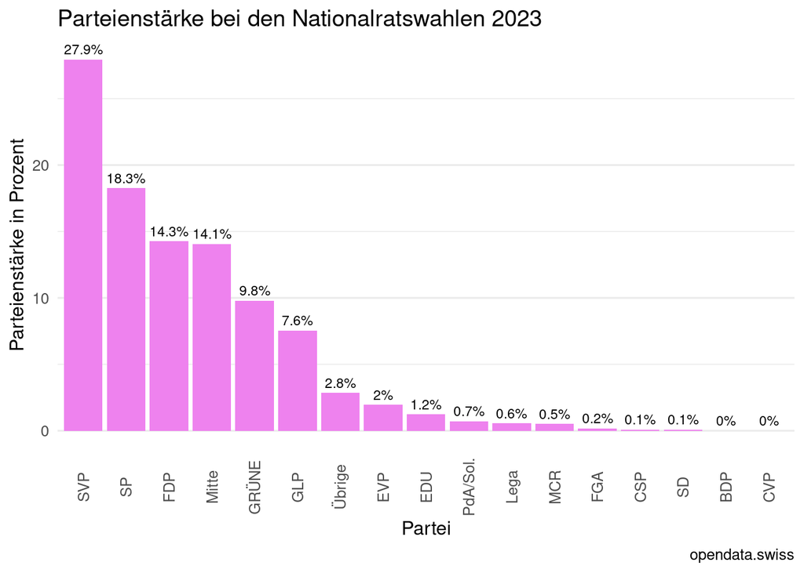

```r
# Visualisierung zur Verteilung der Parteien nach Parteienstärke

ggplot(data = NRW2023_CH_2023_total,
       mapping = aes (y = partei_staerke,
                      x = reorder(partei_bezeichnung_de, -partei_staerke))) +
      geom_col() +
      geom_text(aes(label = paste0(round(partei_staerke, 1), "%")),
                vjust = -0.5, size = 3) +
      theme_minimal() +
      theme_minimal(base_size = 12) +
      theme(panel.grid.major.x = element_blank(),
            axis.text.x = element_text(angle = 90, vjust = 0.5)) +
      geom_col(fill = "violet") +
      labs(title = "Parteienstärke bei den Nationalratswahlen 2023",
            y = "Parteienstärke in Prozent",
            x = "Partei",
           caption = "opendata.swiss")
```

### 2. Direktvergleich der Parteienstärke im Kanton Zürich

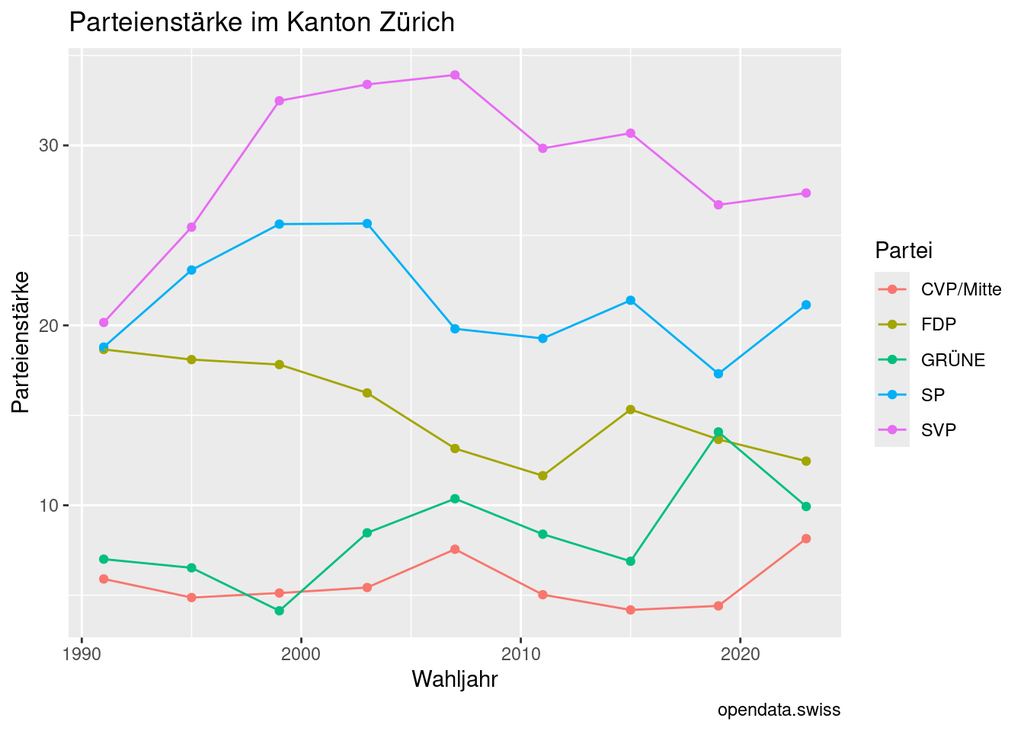

```r
# Direktvergleich der Parteienstärke der letzten neun Nationalratswahlen anhand der fünf grössten Parteien im Kanton Zürich

partei_fuenf_groesste <- c("FDP", "SVP", "SP", "GRÜNE", "CVP/Mitte")

NRW2023_zeitreihe_Kanton |>
 mutate(partei_bezeichnung_de = case_when(
  partei_bezeichnung_de == "CVP" ~ "CVP/Mitte",
  partei_bezeichnung_de == "Mitte" ~ "CVP/Mitte",
  .default = partei_bezeichnung_de
  )) |>
  filter(kanton_bezeichnung == "Zürich") |>
  filter(!is.na(partei_staerke)) |>
  filter(partei_bezeichnung_de %in% partei_fuenf_groesste) |>
  ggplot(mapping = aes(x = wahl_jahr,
                       y = partei_staerke,
                       color = partei_bezeichnung_de)) +
  geom_point() +
  geom_line() +
  labs(title = "Parteienstärke im Kanton Zürich",
            y = "Parteienstärke",
            x = "Wahljahr",
            color = "Partei",
            caption = "opendata.swiss")
```

### 3. Anzahl gewählte Frauen

#### 3.1 Summe der Anzahl gewählter Frauen aller Kantone und Parteien

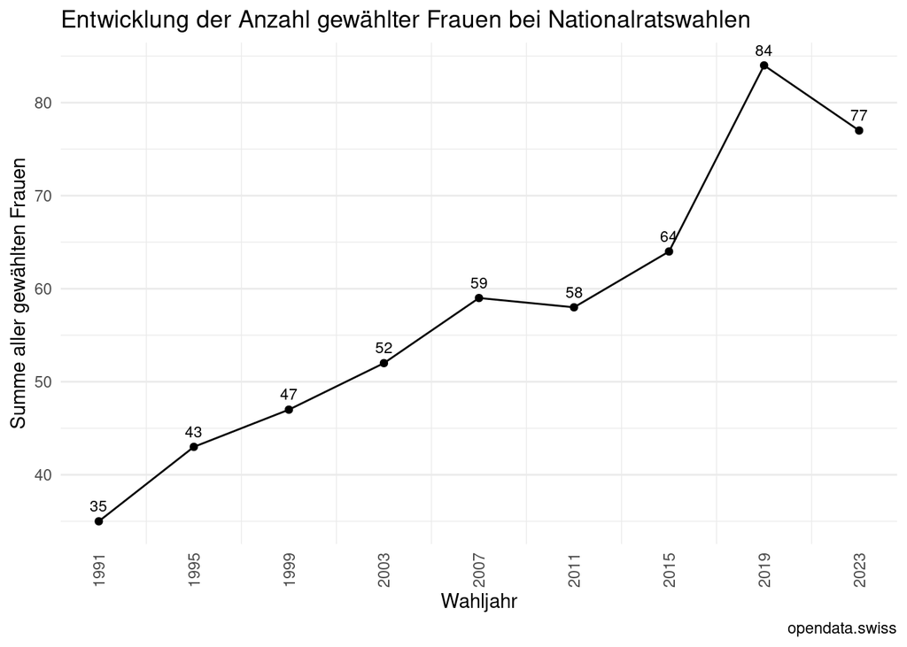

```r
NRW2023_zeitreihe_Kanton |>
  select(wahl_jahr, frauen_anteil, anzahl_gewaehlte_f) |>
  filter(!is.na(anzahl_gewaehlte_f)) |>
  group_by(wahl_jahr) |>
  summarise(sum_anzahl_gewaehlte_f = sum(anzahl_gewaehlte_f)) |>
  ggplot(aes(x = wahl_jahr,
             y = sum_anzahl_gewaehlte_f)) +
  geom_point() +
  scale_x_continuous(breaks = seq(1991, 2023, by = 4)) +
  geom_line() +
  geom_text(aes(label = paste0(round(sum_anzahl_gewaehlte_f, 1))),
                vjust = -0.85, size = 3) +
  theme_minimal() +
      theme_minimal(base_size = 11) +
      theme(panel.grid.major.x = element_blank(),
            axis.text.x = element_text(angle = 90, vjust = 0.5)) +
      labs(title = "Entwicklung der Anzahl gewählter Frauen bei Nationalratswahlen",
            y = "Summe aller gewählten Frauen",
            x = "Wahljahr",
           caption = "opendata.swiss")
```

#### 3.2 Anzahl gewählte Frauen in Table 2

```r
NRW2023_zeitreihe_Kanton |>
  select(wahl_jahr, frauen_anteil, anzahl_gewaehlte_f) |>
  filter(!is.na(anzahl_gewaehlte_f)) |>
  group_by(wahl_jahr) |>
  summarise(sum_anzahl_gewaehlte_f = sum(anzahl_gewaehlte_f))
```

```
# A tibble: 9 × 2
  wahl_jahr sum_anzahl_gewaehlte_f
      <dbl>                  <dbl>
1      1991                     35
2      1995                     43
3      1999                     47
4      2003                     52
5      2007                     59
6      2011                     58
7      2015                     64
8      2019                     84
9      2023                     77
```

```r
gewaehlte_f_prozent <- function(x) {
  round(x / sum(x, na.rm = TRUE) * 100, 1)
}
```

```r
NRW2023_zeitreihe_Kanton |>
  filter(!is.na(anzahl_gewaehlte_f)) |>
  group_by(wahl_jahr) |>
  summarise(sum_anzahl_gewaehlte_f = sum(anzahl_gewaehlte_f)) |>
  mutate(prozent = gewaehlte_f_prozent(sum_anzahl_gewaehlte_f)) |>
  gt::gt()  |>
  gt::tab_header(
    title = "Anzahl gewählte Frauen",
    subtitle = "Nationalratswahlen"
  ) |>
  gt::tab_source_note(
    source_note = gt::md(
      "Datenquelle: [opendata.swiss](https://opendata.swiss/de/dataset/nationalratswahlen-zeitreihen-zu-listen-kandidierenden-parteistarken-mandaten-gewahlten-frauen-)"
    )
  ) |>
  gt::cols_label(
    wahl_jahr = "Wahljahr",
    sum_anzahl_gewaehlte_f = "Anzahl",
    prozent = "Prozent"
  )
```

Table 2: Tabelle 2

Anzahl gewählte Frauen

Nationalratswahlen

| Wahljahr | Anzahl | Prozent |
| --- | --- | --- |
| 1991 | 35 | 6.7 |
| 1995 | 43 | 8.3 |
| 1999 | 47 | 9.1 |
| 2003 | 52 | 10.0 |
| 2007 | 59 | 11.4 |
| 2011 | 58 | 11.2 |
| 2015 | 64 | 12.3 |
| 2019 | 84 | 16.2 |
| 2023 | 77 | 14.8 |

Datenquelle: [opendata.swiss](https://opendata.swiss/de/dataset/nationalratswahlen-zeitreihen-zu-listen-kandidierenden-parteistarken-mandaten-gewahlten-frauen-)

### 4. Entwicklung des Frauen-Anteils auf nationaler sowie auf kantonaler Ebene

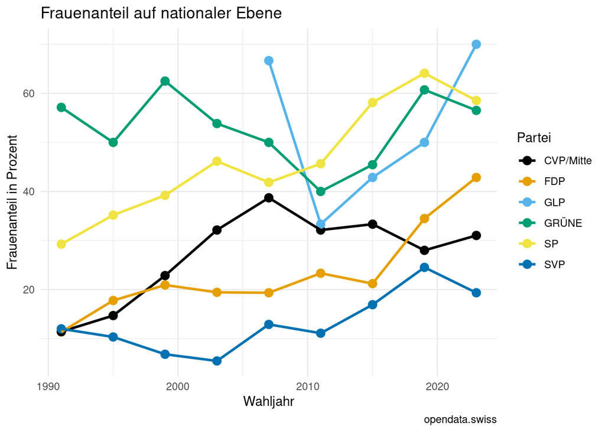

```r
# Entwicklung des Frauen-Anteils der Bundesratsparteien plus die Grünen und die GLP auf nationaler Ebene
# Entwicklung des Frauen-Anteils der Bundesratsparteien plus die Grünen und die GLP im Kanton Zürich

partei_bundespartei <- c("FDP", "SVP", "SP", "GRÜNE", "CVP/Mitte", "GLP")


NRW2023_zeitreihe_CH |>
 mutate(partei_bezeichnung_de = case_when(
  partei_bezeichnung_de == "CVP" ~ "CVP/Mitte",
  partei_bezeichnung_de == "Mitte" ~ "CVP/Mitte",
  .default = partei_bezeichnung_de
  )) |>
  filter(partei_bezeichnung_de %in% partei_bundespartei) |>
  filter(!is.na(frauen_anteil)) |>
  ggplot(mapping = aes(x = wahl_jahr,
                       y = frauen_anteil,
                       color = partei_bezeichnung_de)) +
  geom_point(size = 3) +
  geom_line(size = 1)  +
  scale_color_colorblind() +
  theme_minimal() +
  labs(title = "Frauenanteil auf nationaler Ebene",
            y = "Frauenanteil in Prozent",
            x = "Wahljahr",
            color = "Partei",
            caption = "opendata.swiss")
```

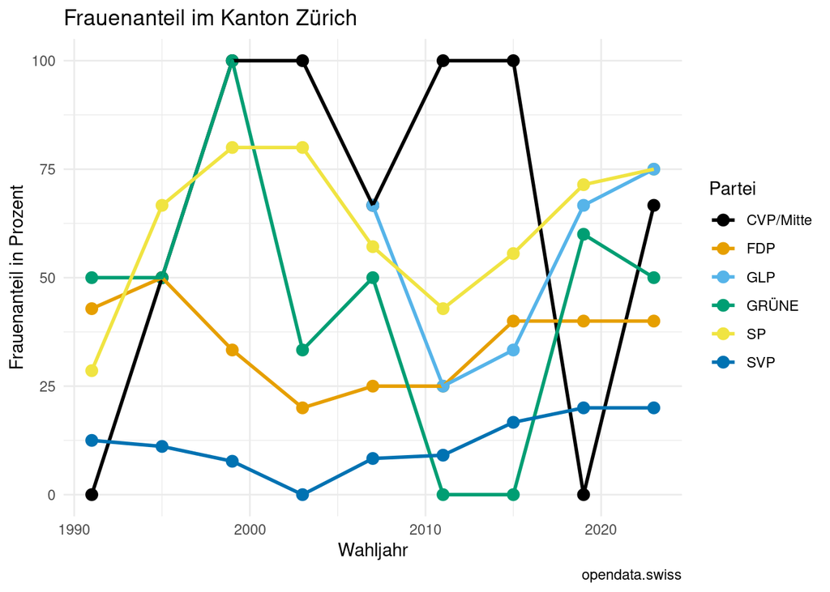

```r
# Entwicklung des Frauen-Anteils der Bundesratsparteien plus die Grünen und die GLP im Kanton Zürich

NRW2023_zeitreihe_Kanton |>
 mutate(partei_bezeichnung_de = case_when(
  partei_bezeichnung_de == "CVP" ~ "CVP/Mitte",
  partei_bezeichnung_de == "Mitte" ~ "CVP/Mitte",
  .default = partei_bezeichnung_de
  )) |>
  filter(!is.na(frauen_anteil)) |>
  filter(kanton_bezeichnung == "Zürich") |>
  filter(partei_bezeichnung_de %in% partei_bundespartei) |>
  ggplot(mapping = aes(x = wahl_jahr,
                       y = frauen_anteil,
                       color = partei_bezeichnung_de)) +
  geom_point(size = 3) +
  geom_line(size = 1)  +
  scale_color_colorblind() +
  theme_minimal() +
  labs(title = "Frauenanteil im Kanton Zürich",
            y = "Frauenanteil in Prozent",
            x = "Wahljahr",
            color = "Partei",
            caption = "opendata.swiss")
```

# Schlussfolgerungen

```r
# Aufbereitete Daten werden in den processed Ordner gescchrieben

write_csv(x = NRW2023_CH_2023,
          here::here("daten/processed/NRW2023_CH_2023"))

write_csv(x = NRW2023_CH_2023_total,
          here::here("daten/processed/NRW2023_CH_2023_total"))

write_csv(x = NRW2023_zeitreihe,
          here::here("daten/processed/NRW2023_zeitreihe"))

write_csv(x = NRW2023_zeitreihe_CH,
          here::here("daten/processed/NRW2023_zeitreihe_CH"))

write_csv(x = NRW2023_zeitreihe_d,
          here::here("daten/processed/NRW2023_zeitreihe_d"))

write_csv(x = NRW2023_zeitreihe_Kanton,
          here::here("daten/processed/NRW2023_zeitreihe_Kanton"))
```